# analysis

We will do an analysis of the dataset first, and next we will answer some predefined questions.

Import data:

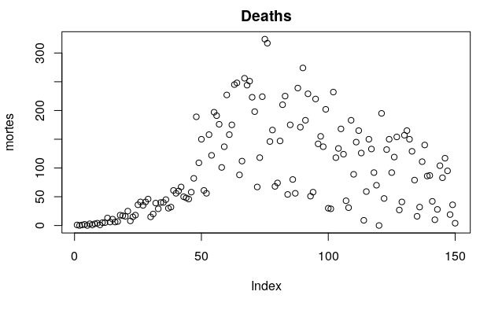

```r
full <- readxl::read_xlsx('covidrj.xlsx', progress = FALSE)
mortes <- diff(full$deaths)
plot(mortes, main = 'Deaths')
```

# Trend

We will now model $Z(t) = T(t) + a_t$.

## Linear model

```r
t = c(1:length(mortes))
deaths = data.frame(mortes = mortes, t = t)
mod = lm(mortes ~ t, data=deaths)
summary(mod)
```

```
Call:
lm(formula = mortes ~ t, data = deaths)

Residuals:
    Min      1Q  Median      3Q     Max
-135,21  -52,30  -26,62   46,54  227,19

Coefficients:
```

```
NAs introduced by coercion
```

```
            Estimate Std. Error t value Pr(>|t|)
(Intercept)  54,4149    12,3662   4,400 2,06e-05 ***
t             0,5653     0,1421   3,979 0,000108 ***
---
Signif. codes:  0 ‘***’ 0,001 ‘**’ 0,01 ‘*’ 0,05 ‘.’ 0,1 ‘ ’ 1

Residual standard error: 75,35 on 148 degrees of freedom
Multiple R-squared:  0,09662,   Adjusted R-squared:  0,09051
F-statistic: 15,83 on 1 and 148 DF,  p-value: 0,0001082
```

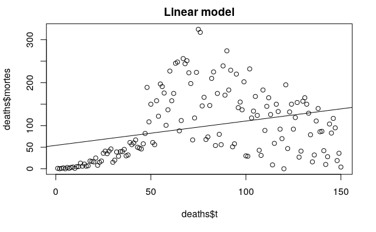

```r
plot(deaths$t, deaths$mortes, main = 'Linear model')
abline(mod$coefficients)
```

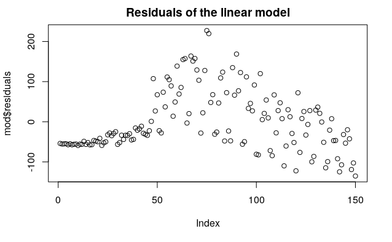

```r
plot(mod$residuals, main = 'Residuals of the linear model')
```

It seems not a good a idea.

## Polynomial model

```r
mod = lm(mortes ~ poly(t, 2), data = deaths)
summary(mod)
```

```
Call:
lm(formula = mortes ~ poly(t, 2), data = deaths)

Residuals:
     Min       1Q   Median       3Q      Max
-120,982  -38,321   -5,518   38,656  174,075

Coefficients:
```

```
NAs introduced by coercion
```

```
            Estimate Std. Error t value Pr(>|t|)
(Intercept)    97,09       4,77  20,355  < 2e-16 ***
poly(t, 2)1   299,78      58,42   5,131 8,95e-07 ***
poly(t, 2)2  -581,87      58,42  -9,960  < 2e-16 ***
---
Signif. codes:  0 ‘***’ 0,001 ‘**’ 0,01 ‘*’ 0,05 ‘.’ 0,1 ‘ ’ 1

Residual standard error: 58,42 on 147 degrees of freedom
Multiple R-squared:  0,4606,    Adjusted R-squared:  0,4533
F-statistic: 62,77 on 2 and 147 DF,  p-value: < 2,2e-16
```

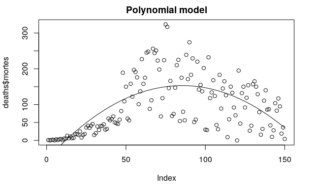

```r
prediction = predict(mod, data.frame(deaths$t))
plot(deaths$mortes, main = 'Polynomial model')
lines(prediction)
```

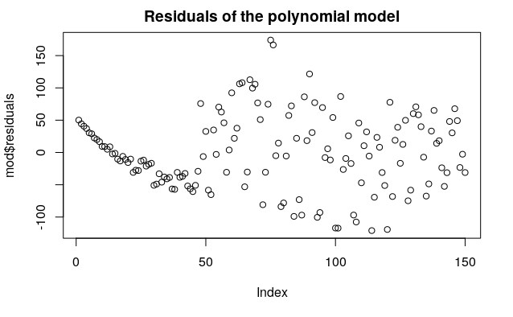

```r
plot(mod$residuals, main = 'Residuals of the polynomial model')
```

We see better results.

## Moving average

```r
w1 = filter(x = deaths$mortes, filter = rep(1/7, 7), sides = 2)
w2 = filter(x = deaths$mortes, filter = rep(1/14, 14), sides = 2)
w3 = filter(x = deaths$mortes, filter = rep(1/39, 30), sides = 2)
plot(deaths$mortes, main = 'Moving average')
lines(w1, col='red')
```

```r
lines(w2, col='blue')
lines(w3, col='green')
```

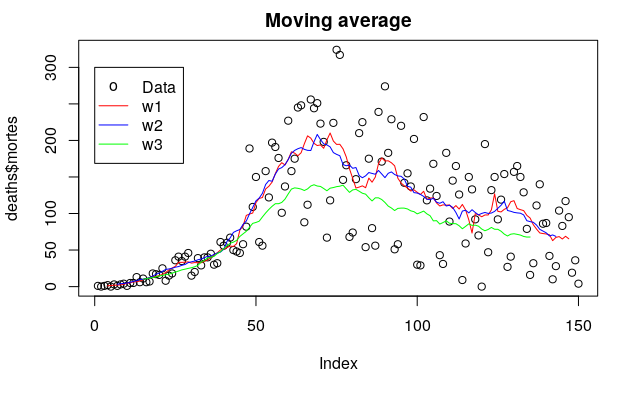

```r
legend(
  x = 0,
  y = 300,
  legend = c('Data', 'w1', 'w2', 'w3'),
  col = c('black', 'red', 'blue', 'green'),
  pch = c('o', '', '', ''),
  lty = c(0, 1, 1, 1)
)
```

## LOWESS

```r
lw1 = lowess(x = deaths$mortes, f=0.5)
lw2 = lowess(x = deaths$mortes, f=0.2)
plot(deaths$mortes, main = 'LOWESS')
lines(lw1, col='red')
```

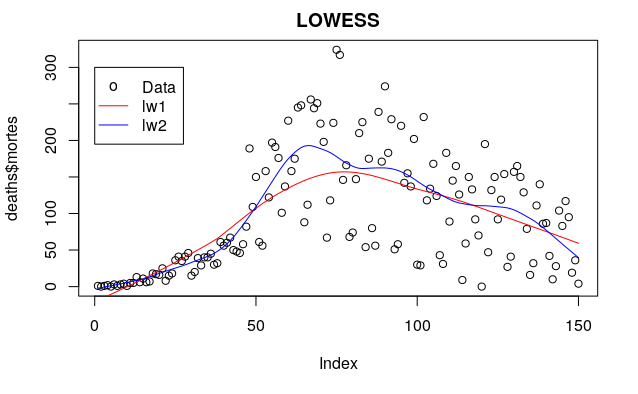

```r
lines(lw2, col='blue')
legend(
  x = 0,
  y = 300,
  legend = c('Data', 'lw1', 'lw2'),
  col = c('black', 'red', 'blue'),
  pch = c('o', '', ''),
  lty = c(0, 1, 1)
)
```

## Differentiation and ACF

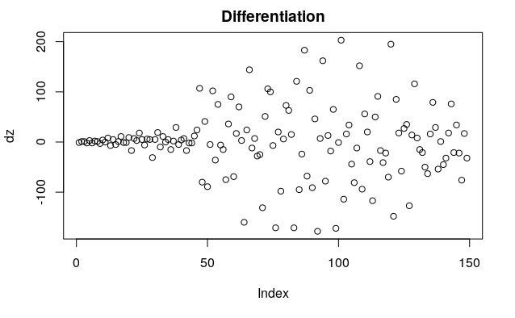

```r
dz = diff(deaths$mortes, lag = 1)
plot(dz, main = 'Differentiation')
```

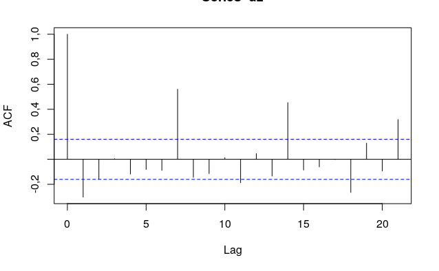

```r
acf(x = dz)
```

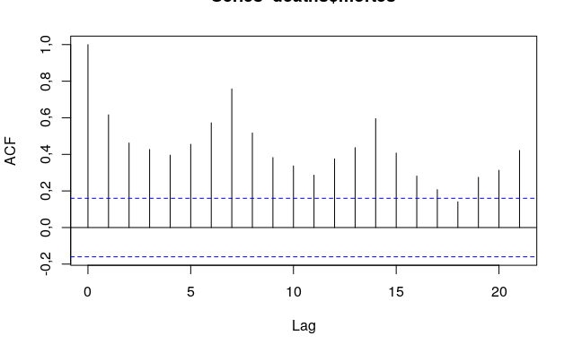

```r
acf(deaths$mortes)
```

Diff is a good idea.

## Trend test

```
    Runs Test

data:  deaths$mortes
statistic = -7,3733, runs = 31, n1 = 75, n2 = 75, n = 150, p-value = 1,665e-13
alternative hypothesis: nonrandomness
```

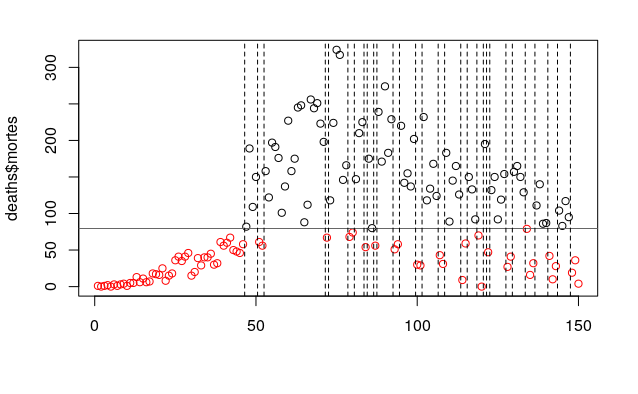

```r
library(randtests)
runs.test(x = deaths$mortes, alternative = "two.sided", plot = TRUE)
```

# Seasonality

We will now model $Z(t) = T(t) + S(t) + a_t$.

## Deterministic seasonality

```r
# Seasonal dummies
N = length(deaths$mortes)
Q = factor(c(rep(c(1:7), N/7), c(1:(N%%7))))
deaths$Q = Q
mod = lm(mortes ~ t+Q, data = deaths)
summary(mod)
```

```
Call:
lm(formula = mortes ~ t + Q, data = deaths)

Residuals:
     Min       1Q   Median       3Q      Max
-128,387  -56,262   -5,917   38,079  205,952

Coefficients:
```

```
NAs introduced by coercion
```

```
            Estimate Std. Error t value Pr(>|t|)
(Intercept)  59,7542    17,3898   3,436 0,000774 ***
t             0,5719     0,1285   4,452 1,71e-05 ***
Q2          -57,4810    20,5344  -2,799 0,005835 **
Q3          -57,7348    20,5356  -2,811 0,005630 **
Q4           29,3033    20,7771   1,410 0,160618
Q5           15,3980    20,7771   0,741 0,459853
Q6           28,4927    20,7779   1,371 0,172444
Q7            5,7779    20,7795   0,278 0,781371
---
Signif. codes:  0 ‘***’ 0,001 ‘**’ 0,01 ‘*’ 0,05 ‘.’ 0,1 ‘ ’ 1

Residual standard error: 68,1 on 142 degrees of freedom
Multiple R-squared:  0,2919,    Adjusted R-squared:  0,257
F-statistic: 8,363 on 7 and 142 DF,  p-value: 1,545e-08
```

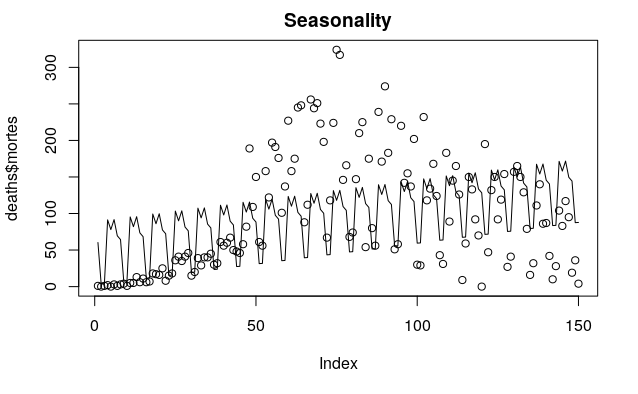

```r
plot(deaths$mortes, main = "Seasonality")
lines(mod$fitted.values)
```

## Log scale (multiplicative)

```r
index = deaths$mortes != 0
mod = lm(log(mortes[index]) ~ t[index]+Q[index], data = deaths)
summary(mod)
```

```
Call:
lm(formula = log(mortes[index]) ~ t[index] + Q[index], data = deaths)

Residuals:
    Min      1Q  Median      3Q     Max
-3,2331 -0,6169  0,1391  0,8363  1,8807

Coefficients:
```

```
NAs introduced by coercion
```

```
             Estimate Std. Error t value Pr(>|t|)
(Intercept)  2,968000   0,279189  10,631  < 2e-16 ***
t[index]     0,014840   0,002081   7,131 4,98e-11 ***
Q[index]2   -0,692973   0,332822  -2,082   0,0392 *
Q[index]3   -0,804279   0,328847  -2,446   0,0157 *
Q[index]4    0,356512   0,332551   1,072   0,2856
Q[index]5    0,375634   0,336908   1,115   0,2668
Q[index]6    0,378770   0,332621   1,139   0,2568
Q[index]7    0,161179   0,332675   0,484   0,6288
---
Signif. codes:  0 ‘***’ 0,001 ‘**’ 0,01 ‘*’ 0,05 ‘.’ 0,1 ‘ ’ 1

Residual standard error: 1,078 on 139 degrees of freedom
Multiple R-squared:  0,3606,    Adjusted R-squared:  0,3284
F-statistic:  11,2 on 7 and 139 DF,  p-value: 3,404e-11
```

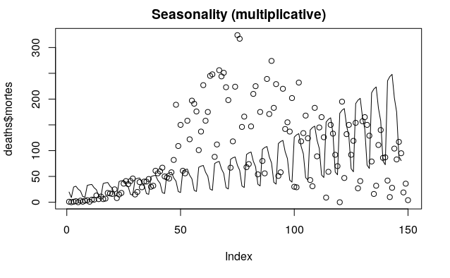

```r
plot(deaths$mortes, main = "Seasonality (multiplicative)")
lines(exp(mod$fitted.values))
```

Better in logarithmic scale.

## Stochastic seasonality

```r
trend = filter(deaths$mortes, sides = 2, filter = rep(1/7, 7))
mod = lm(mortes ~ Q-1, data=deaths)
summary(mod)
```

```
Call:
lm(formula = mortes ~ Q - 1, data = deaths)

Residuals:
    Min      1Q  Median      3Q     Max
-129,38  -44,77   -0,31   46,04  205,95

Coefficients:
```

```
NAs introduced by coercion
```

```
   Estimate Std. Error t value Pr(>|t|)
Q1   102,36      15,45   6,627 6,48e-10 ***
Q2    45,45      15,45   2,943  0,00380 **
Q3    45,77      15,45   2,963  0,00356 **
Q4   131,38      15,81   8,310 6,69e-14 ***
Q5   118,05      15,81   7,467 7,39e-12 ***
Q6   131,71      15,81   8,331 5,94e-14 ***
Q7   109,57      15,81   6,931 1,32e-10 ***
---
Signif. codes:  0 ‘***’ 0,001 ‘**’ 0,01 ‘*’ 0,05 ‘.’ 0,1 ‘ ’ 1

Residual standard error: 72,45 on 143 degrees of freedom
Multiple R-squared:  0,6798,    Adjusted R-squared:  0,6642
F-statistic: 43,38 on 7 and 143 DF,  p-value: < 2,2e-16
```

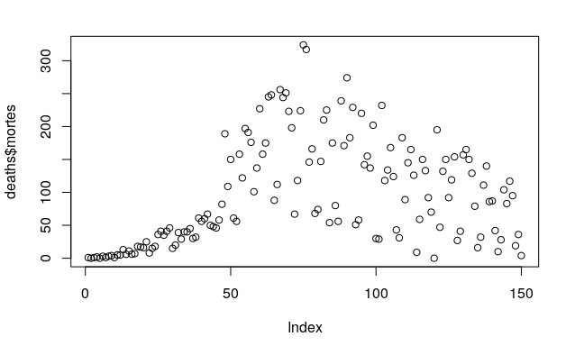

```r
S = mod$fitted.values
plot(deaths$mortes)
```

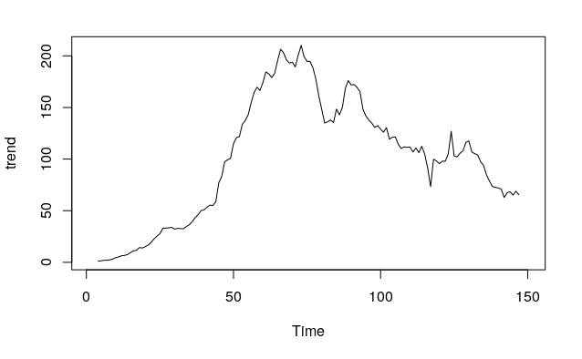

```r
plot(trend)
```

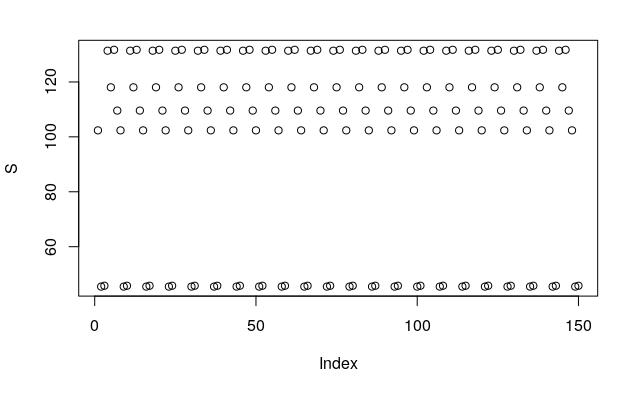

```r
plot(S)
```

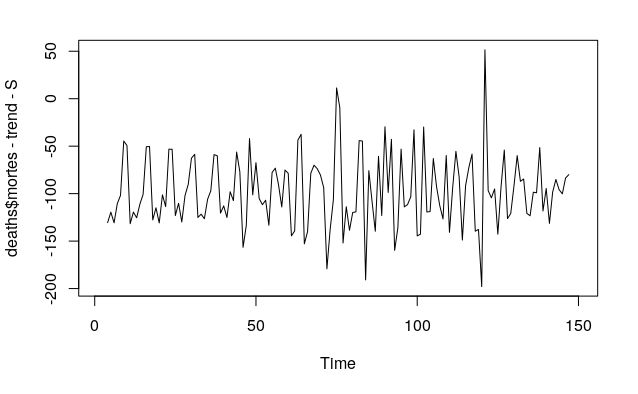

```r
plot(deaths$mortes - trend - S)
```

## Decompose

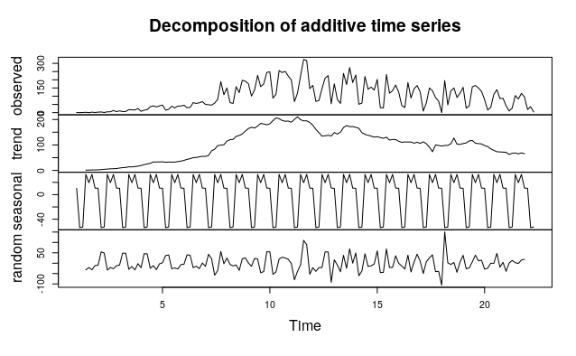

```r
plot(decompose(ts(deaths$mortes, frequency = 7)))
```

## LOWESS

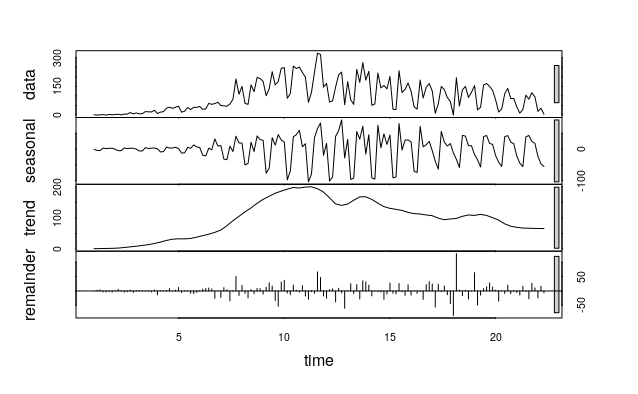

```r
plot(stl(ts(deaths$mortes, frequency = 7), s.window = 7))
```

## Kruskal-Wallis

```r
trend = decompose(ts(deaths$mortes, frequency = 7))$trend
deaths$detrended = deaths$mortes - trend
kruskal.test(detrended ~ Q, data = deaths)
```

```
    Kruskal-Wallis rank sum test

data:  detrended by Q
Kruskal-Wallis chi-squared = 66,855, df = 6, p-value = 1,802e-12
```

We reject the hypothesis of non seasonality.

## Analysis of variance

```r
mod <- lm(detrended~Q-1, na.action = na.omit, data = deaths)
summary(mod)
```

```
Call:
lm(formula = detrended ~ Q - 1, data = deaths, na.action = na.omit)

Residuals:
     Min       1Q   Median       3Q      Max
-105,700  -26,173   -4,462   24,985  150,864

Coefficients:
```

```
NAs introduced by coercion
```

```
   Estimate Std. Error t value Pr(>|t|)
Q1   10,129      8,693   1,165 0,245972
Q2  -53,864      8,693  -6,196 6,34e-09 ***
Q3  -52,779      8,693  -6,072 1,17e-08 ***
Q4   32,707      8,483   3,856 0,000177 ***
Q5   19,252      8,483   2,269 0,024807 *
Q6   32,673      8,483   3,852 0,000180 ***
Q7   10,510      8,483   1,239 0,217487
---
Signif. codes:  0 ‘***’ 0,001 ‘**’ 0,01 ‘*’ 0,05 ‘.’ 0,1 ‘ ’ 1

Residual standard error: 38,88 on 137 degrees of freedom
  (6 observations deleted due to missingness)
Multiple R-squared:  0,452, Adjusted R-squared:  0,424
F-statistic: 16,14 on 7 and 137 DF,  p-value: 2,28e-15
```

## Questions

1. Is the series stationary?

Clearly we see we have trend and seasonality, so it’s not stationary.

2. Is there some seasonality?

3. Is there some trend?

There is a trend. All models shows that. We also did a test and confirmed that.

4. Is logarithmic scale model better (multiplicative model)?

The $R^2$ for log scale is better.

5. Does the sequence test show trend?

Yes.

6. Do any of the tests studied in class show seasonality?

Yes.